# Laboratorio Otros Modelos de Clasifiación IN5602 - Semestre Primavera 2021

Sebastián Urbina

25-11-2021

# Desarollo del laboratorio

## El Problema

Trabajarán con una base de datos sobre cáncer de mamas. El objetivo es desarrollar un modelo de ml que logre identificar cancer de mamas según las características presentadas en la base de datos. Esta posee 9 variables variables explicativas que se listan a continuación:

- Sample code number id number
- Clump Thickness 1 - 10
- Uniformity of Cell Size 1 - 10
- Uniformity of Cell Shape 1 - 10
- Marginal Adhesion 1 - 10
- Single Epithelial Cell Size 1 - 10
- Bare Nuclei 1 - 10
- Bland Chromatin 1 - 10
- Normal Nucleoli 1 - 10
- Mitoses 1 - 10
- Class: (2 for benign, 4 for malignant)

## Carga de datos y EDA

```r
# Librerias
library(caret)
library(readr)
library(dplyr)
library(corrplot)  #Para realizar correlogramas
cancer_mamas<-read.csv(file="E:/Sebas/Escritorio/2021-2/Marketing II/Lab4/cancer.csv", header=TRUE, sep=";")

#Realice un EDA simple con el objetivo de ver las correlaciones entre la variable de interés y la clase
```

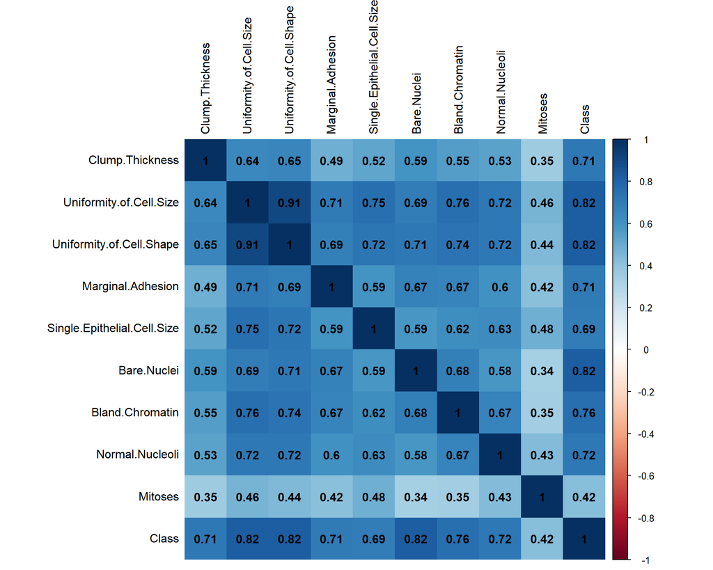

```r
#Exploración de datos
correlacion <- cor(subset((select_if(cancer_mamas, is.numeric)),select=-c(1)));
corrplot(correlacion, method = "shade", shade.col = NA, tl.col = "black", tl.srt = 90, addCoef.col = "black", number.digits=2)
```

## División Data

```r
#Se cambian valores de las clases
cancer_mamas$Class <- ifelse(cancer_mamas$Class==2, 'yes', 'no')

### Se definen los datos de entrenamiento y de test
train <- sample(1:nrow(cancer_mamas), size=round(0.8*nrow(cancer_mamas),0)) #indice aleatorio para los datos de entrenamiento

cancer_mamas.train <- cancer_mamas[train,]
cancer_mamas.test  <- cancer_mamas[-train,]
```

## Preguntas

Para responder estar preguntas sugiero ver la clase de otros modelos de clasificación y los códigos que se mostraron.

##### **Pregunta 1**

Como se deben escoger 3 variables, en base al gráfico de correlación realizado en el análisis exploratorio. Se utilizarán: `Uniformity.of.Cell.Size`, `Bare.Nuclei` y `Bland.Chromatin`, en base a que son las que tienen mayor correlación respecto a la variable a predecir. Cabe destacar que se ignoró `Uniformity.Of.Cell.Shape` porque está bastante correlacionada con la de elegida de Size.

Como se está trabajando con datos sensibles de salud y queremos evitar los Falsos Negativos, pues implicaría que una persona enferma no sería considerada bajo un tratamiento. Se utilizará como métrica esencial `Recall` o `Sensivity`, ya que mide la cantidad de Falsos Negativos en las predicciones del modelo. Luego, como métrica segundaria se utilizará `Accuracy`.

##### **Pregunta 2**

Primero entrenamos un **Support Vector Machine(SVM)**, con 5-fold cross-validation y probando 5 parámetros distintos.

```r
# Corra 2 modelos de clasificación use las variables seleccionadas anteriormente para predecir la existencia de cáncer de mamas.
# Cálcule para cada modelo las metricas seleccionadas para el set de entrenamiento y de testeo, además grafique la matriz de confusión para ambos.
# Comente sobre los resultados, ¿se observa overfitting o underfitting?
# confusionMatrix(pred_vali, vali$target)
library(MLmetrics) #Cargamos esta librería para utilizar Accuracy
train.svm <- train(Class ~ Uniformity.of.Cell.Size+Bare.Nuclei+Bland.Chromatin, data=cancer_mamas.train, method="svmLinear2",
                   trControl  = trainControl("cv", number=5, classProbs=TRUE, summaryFunction=multiClassSummary),
                   preProcess = c("center","scale"),
                   tuneLength = 5,
                   metric = "Recall")
train.svm
```

```
## Support Vector Machines with Linear Kernel
##
## 546 samples
##   3 predictor
##   2 classes: 'no', 'yes'
##
## Pre-processing: centered (3), scaled (3)
## Resampling: Cross-Validated (5 fold)
## Summary of sample sizes: 437, 437, 437, 437, 436
## Resampling results across tuning parameters:
##
##   cost  logLoss    AUC        prAUC      Accuracy   Kappa      F1
##   0.25  0.1191260  0.9927998  0.8393144  0.9614679  0.9159793  0.9458031
##   0.50  0.1190904  0.9924367  0.8388372  0.9633028  0.9202549  0.9488284
##   1.00  0.1191934  0.9919971  0.8381143  0.9651376  0.9243074  0.9514828
##   2.00  0.1196238  0.9919971  0.8381101  0.9633028  0.9205013  0.9491943
##   4.00  0.1178586  0.9917781  0.8376745  0.9633028  0.9205013  0.9491943
##   Sensitivity  Specificity  Pos_Pred_Value  Neg_Pred_Value  Precision
##   0.9297436    0.9798344    0.9646516       0.9611454       0.9646516
##   0.9347436    0.9798344    0.9645946       0.9634372       0.9645946
##   0.9397436    0.9798344    0.9649604       0.9662505       0.9649604
##   0.9397436    0.9769358    0.9605470       0.9661627       0.9605470
##   0.9397436    0.9769358    0.9605470       0.9661627       0.9605470
##   Recall     Detection_Rate  Balanced_Accuracy
##   0.9297436  0.3387823       0.9547890
##   0.9347436  0.3406172       0.9572890
##   0.9397436  0.3424520       0.9597890
##   0.9397436  0.3424520       0.9583397
##   0.9397436  0.3424520       0.9583397
##
## Recall was used to select the optimal model using the largest value.
## The final value used for the model was cost = 1.
```

Ahora calculamos la predicción y posteriormente la matriz de confusión.

```r
predictSVM = predict(train.svm, newdata = cancer_mamas.test)

true_choice = cancer_mamas.test$Class #formateamos los datos de testeo a X1,X2,X3,X4 para poder compararlos

MatrizConfSVM = table(true_choice , predictSVM)
MatrizConfSVM
```

```
##            predictSVM
## true_choice no yes
##         no  35   5
##         yes  4  93
```

```r
set.seed(1)
train.rf <- train(Class ~ Uniformity.of.Cell.Size+Bare.Nuclei+Bland.Chromatin, data=cancer_mamas.train, method="parRF",
                  trControl=trainControl("cv", number=5, allowParallel=TRUE, classProbs=TRUE,
                  summaryFunction=multiClassSummary),
                  preProcess=c("center","scale"),
                  tuneLength=5,
                  metric="Recall")
train.rf
```

```
## Parallel Random Forest
##
## 546 samples
##   3 predictor
##   2 classes: 'no', 'yes'
##
## Pre-processing: centered (3), scaled (3)
## Resampling: Cross-Validated (5 fold)
## Summary of sample sizes: 437, 438, 436, 436, 437
## Resampling results across tuning parameters:
##
##   mtry  logLoss    AUC        prAUC      Accuracy   Kappa      F1
##   2     0.1365536  0.9916065  0.3199369  0.9450360  0.8821180  0.9256932
##   3     0.2016777  0.9903282  0.2941681  0.9431841  0.8782764  0.9233711
##   Sensitivity  Specificity  Pos_Pred_Value  Neg_Pred_Value  Precision
##   0.9398718    0.9480331    0.9134015       0.9653914       0.9134015
##   0.9397436    0.9451346    0.9095773       0.9655285       0.9095773
##   Recall     Detection_Rate  Balanced_Accuracy
##   0.9398718  0.3425138       0.9439525
##   0.9397436  0.3424968       0.9424391
##
## Recall was used to select the optimal model using the largest value.
## The final value used for the model was mtry = 2.
```

Al igual que antes, predecidmos y creamos la matriz de confusión.

```r
predictRF = predict(train.rf, newdata = cancer_mamas.test)

#Se crea la matriz de confusión
MatrizConfRF= table(true_choice , predictRF)
MatrizConfRF
```

```
##            predictRF
## true_choice no yes
##         no  37   3
##         yes  4  93
```

En base a observar las matrices de confusión no se observa *overfitting*, pues ambos modelos predicen igual de bien que en los datos de entrenamiento.

Incluso si calculamos el Accuracy para los modelos, se tienen valores similares a lo que entregan los modelos sobre los datos de entrenamientos. Estos nos indica que los modelos a priori generalizan bien.

$$Accuracy_{SVM}=\frac{35+93}{137}=0.934$$
$$Accuracy_{RF}=\frac{37+93}{137}=0.949$$

##### **Pregunta 3**

Para mostrar los resultados y la matriz de confusión se utilizará la librería `cvms`, la cual permite graficar con diseño.

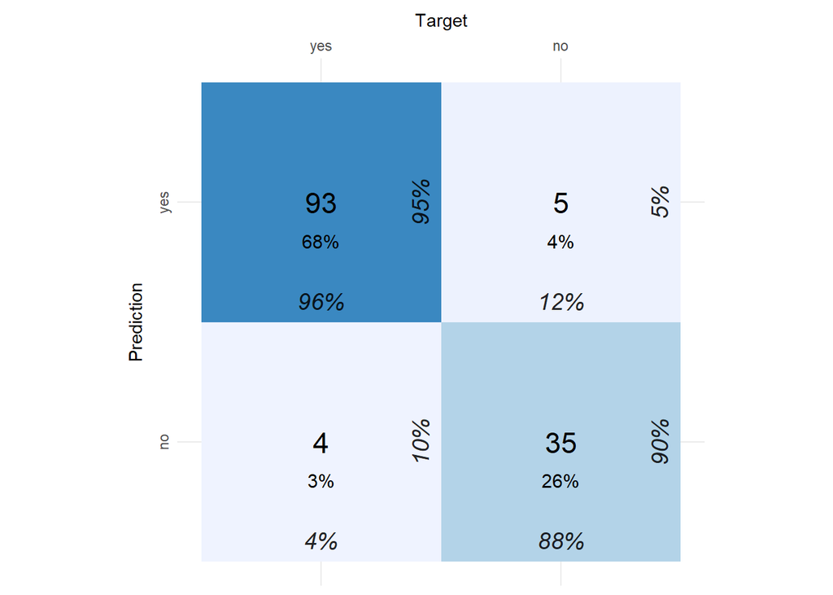

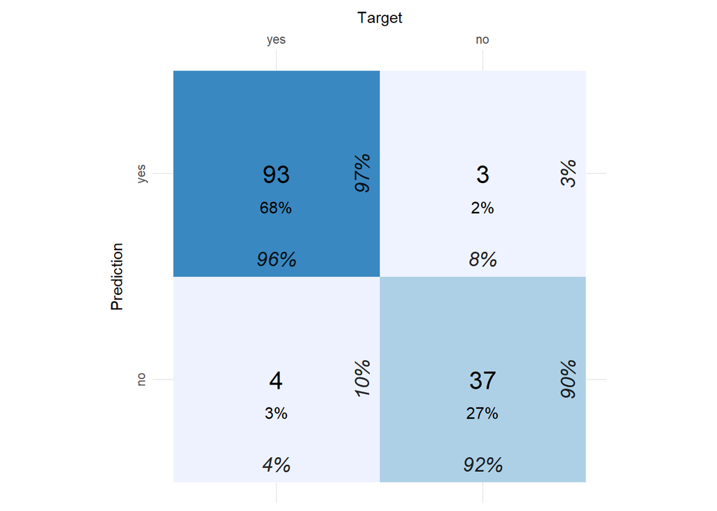

```r
library(cvms)

cfm_svm <- as_tibble(MatrizConfSVM) #Transformamos la matriz confusión de SVM al formato requerido
cfm_rf <- as_tibble(MatrizConfRF)   #Transformamos la matriz confusión de RF al formato requerido



## Creamos los gráficos de los modelos ML
plot_confusion_matrix(cfm_svm,
                      target_col = "true_choice",
                      prediction_col = "predictSVM",
                      counts_col = "n",
                      digits=0,
                      counts_on_top = TRUE,
                      font_counts = font(size=6),
                      font_normalized = font(size=4),
                      font_col_percentages = font(size=5),
                      font_row_percentages = font(size=5))

plot_confusion_matrix(cfm_rf,
                      target_col = "true_choice",
                      prediction_col = "predictRF",
                      counts_col = "n",
                      digits=0,
                      counts_on_top = TRUE,
                      font_counts = font(size=6),
                      font_normalized = font(size=4),
                      font_col_percentages = font(size=5),
                      font_row_percentages = font(size=5))
```

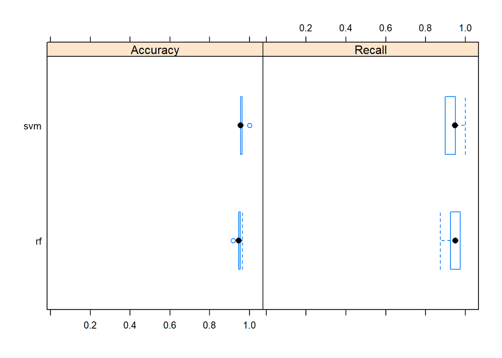

```r
results <- resamples(list(svm=train.svm, rf=train.rf))
bwplot(results)[c(1,12)]
```